# DATA 621 – Business Analytics and Data Mining

Homework 5

Ramnivas Singh

2022-05-19

## Wine Prediction

Our goal is to explore, analyze and model a dataset containing information on approximately 12,000 commercially available wines. The variables are mostly related to the chemical properties of the wine being sold. The response variable is the number of sample cases of wine that were purchased by wine distribution companies after sampling a wine. These cases would be used to provide tasting samples to restaurants and wine stores around the United States. The more sample cases purchased, the more likely is a wine to be sold at a high end restaurant.

A large wine manufacturer is studying the data in order to predict the number of wine cases ordered based upon the wine characteristics. If the wine manufacturer can predict the number of cases, then that manufacturer will be able to adjust their wine offering to maximize sales.

Your objective is to build a count regression model to predict the number of cases of wine that will be sold given certain properties of the wine.

#### Load the required libraries

```r
library(dplyr)
library(ggplot2)
library(stringr)
library(mice)
library(tidyr)
library(corrplot)
library(VIM)
library(MASS)
library(magrittr)
library(pscl)
```

#### Loading data and doing the exploratory data analysis

```r
wine_raw <- read.csv("https://raw.githubusercontent.com/deepakmongia/Data621/master/HW-5/data/wine-training-data.csv",
                     header = TRUE, row.names = 1)

print(head(wine_raw))
```

```
##   TARGET FixedAcidity VolatileAcidity CitricAcid ResidualSugar Chlorides
## 1      3          3.2           1.160      -0.98          54.2    -0.567
## 2      3          4.5           0.160      -0.81          26.1    -0.425
## 4      5          7.1           2.640      -0.88          14.8     0.037
## 5      3          5.7           0.385       0.04          18.8    -0.425
## 6      4          8.0           0.330      -1.26           9.4        NA
## 7      0         11.3           0.320       0.59           2.2     0.556
##   FreeSulfurDioxide TotalSulfurDioxide Density   pH Sulphates Alcohol
## 1                NA                268 0.99280 3.33     -0.59     9.9
## 2                15               -327 1.02792 3.38      0.70      NA
## 4               214                142 0.99518 3.12      0.48    22.0
## 5                22                115 0.99640 2.24      1.83     6.2
## 6              -167                108 0.99457 3.12      1.77    13.7
## 7               -37                 15 0.99940 3.20      1.29    15.4
##   LabelAppeal AcidIndex STARS
## 1           0         8     2
## 2          -1         7     3
## 4          -1         8     3
## 5          -1         6     1
## 6           0         9     2
## 7           0        11    NA
```

```r
print(dim(wine_raw))
```

```
## [1] 12795    15
```

```r
print(str(wine_raw))
```

```
## 'data.frame':    12795 obs. of  15 variables:
##  $ TARGET            : int  3 3 5 3 4 0 0 4 3 6 ...
##  $ FixedAcidity      : num  3.2 4.5 7.1 5.7 8 11.3 7.7 6.5 14.8 5.5 ...
##  $ VolatileAcidity   : num  1.16 0.16 2.64 0.385 0.33 0.32 0.29 -1.22 0.27 -0.22 ...
##  $ CitricAcid        : num  -0.98 -0.81 -0.88 0.04 -1.26 0.59 -0.4 0.34 1.05 0.39 ...
##  $ ResidualSugar     : num  54.2 26.1 14.8 18.8 9.4 ...
##  $ Chlorides         : num  -0.567 -0.425 0.037 -0.425 NA 0.556 0.06 0.04 -0.007 -0.277 ...
##  $ FreeSulfurDioxide : num  NA 15 214 22 -167 -37 287 523 -213 62 ...
##  $ TotalSulfurDioxide: num  268 -327 142 115 108 15 156 551 NA 180 ...
##  $ Density           : num  0.993 1.028 0.995 0.996 0.995 ...
##  $ pH                : num  3.33 3.38 3.12 2.24 3.12 3.2 3.49 3.2 4.93 3.09 ...
##  $ Sulphates         : num  -0.59 0.7 0.48 1.83 1.77 1.29 1.21 NA 0.26 0.75 ...
##  $ Alcohol           : num  9.9 NA 22 6.2 13.7 15.4 10.3 11.6 15 12.6 ...
##  $ LabelAppeal       : int  0 -1 -1 -1 0 0 0 1 0 0 ...
##  $ AcidIndex         : int  8 7 8 6 9 11 8 7 6 8 ...
##  $ STARS             : int  2 3 3 1 2 NA NA 3 NA 4 ...
## NULL
```

```r
print(summary(wine_raw))
```

```
##      TARGET       FixedAcidity     VolatileAcidity     CitricAcid
##  Min.   :0.000   Min.   :-18.100   Min.   :-2.7900   Min.   :-3.2400
##  1st Qu.:2.000   1st Qu.:  5.200   1st Qu.: 0.1300   1st Qu.: 0.0300
##  Median :3.000   Median :  6.900   Median : 0.2800   Median : 0.3100
##  Mean   :3.029   Mean   :  7.076   Mean   : 0.3241   Mean   : 0.3084
##  3rd Qu.:4.000   3rd Qu.:  9.500   3rd Qu.: 0.6400   3rd Qu.: 0.5800
##  Max.   :8.000   Max.   : 34.400   Max.   : 3.6800   Max.   : 3.8600
##
##  ResidualSugar        Chlorides       FreeSulfurDioxide TotalSulfurDioxide
##  Min.   :-127.800   Min.   :-1.1710   Min.   :-555.00   Min.   :-823.0
##  1st Qu.:  -2.000   1st Qu.:-0.0310   1st Qu.:   0.00   1st Qu.:  27.0
##  Median :   3.900   Median : 0.0460   Median :  30.00   Median : 123.0
##  Mean   :   5.419   Mean   : 0.0548   Mean   :  30.85   Mean   : 120.7
##  3rd Qu.:  15.900   3rd Qu.: 0.1530   3rd Qu.:  70.00   3rd Qu.: 208.0
##  Max.   : 141.150   Max.   : 1.3510   Max.   : 623.00   Max.   :1057.0
##  NA's   :616        NA's   :638       NA's   :647       NA's   :682
##     Density             pH          Sulphates          Alcohol
##  Min.   :0.8881   Min.   :0.480   Min.   :-3.1300   Min.   :-4.70
##  1st Qu.:0.9877   1st Qu.:2.960   1st Qu.: 0.2800   1st Qu.: 9.00
##  Median :0.9945   Median :3.200   Median : 0.5000   Median :10.40
##  Mean   :0.9942   Mean   :3.208   Mean   : 0.5271   Mean   :10.49
##  3rd Qu.:1.0005   3rd Qu.:3.470   3rd Qu.: 0.8600   3rd Qu.:12.40
##  Max.   :1.0992   Max.   :6.130   Max.   : 4.2400   Max.   :26.50
##                   NA's   :395     NA's   :1210      NA's   :653
##   LabelAppeal          AcidIndex          STARS
##  Min.   :-2.000000   Min.   : 4.000   Min.   :1.000
##  1st Qu.:-1.000000   1st Qu.: 7.000   1st Qu.:1.000
##  Median : 0.000000   Median : 8.000   Median :2.000
##  Mean   :-0.009066   Mean   : 7.773   Mean   :2.042
##  3rd Qu.: 1.000000   3rd Qu.: 8.000   3rd Qu.:3.000
##  Max.   : 2.000000   Max.   :17.000   Max.   :4.000
##                                       NA's   :3359
```

#### Check blank or missing data

We are now checking if there is any blank or NA data

```r
### Blank data
train_missing_df <- data.frame(apply(wine_raw, 2, function(x) length(which(x == ''))))
print(train_missing_df)
```

```
##                    apply.wine_raw..2..function.x..length.which.x.........
## TARGET                                                                  0
## FixedAcidity                                                            0
## VolatileAcidity                                                         0
## CitricAcid                                                              0
## ResidualSugar                                                           0
## Chlorides                                                               0
## FreeSulfurDioxide                                                       0
## TotalSulfurDioxide                                                      0
## Density                                                                 0
## pH                                                                      0
## Sulphates                                                               0
## Alcohol                                                                 0
## LabelAppeal                                                             0
## AcidIndex                                                               0
## STARS                                                                   0
```

```r
### NA data
train_na_df1 <- data.frame(apply(wine_raw, 2, function(x) length(which(is.na(x)))))
print(train_na_df1)
```

```
##                    apply.wine_raw..2..function.x..length.which.is.na.x....
## TARGET                                                                   0
## FixedAcidity                                                             0
## VolatileAcidity                                                          0
## CitricAcid                                                               0
## ResidualSugar                                                          616
## Chlorides                                                              638
## FreeSulfurDioxide                                                      647
## TotalSulfurDioxide                                                     682
## Density                                                                  0
## pH                                                                     395
## Sulphates                                                             1210
## Alcohol                                                                653
## LabelAppeal                                                              0
## AcidIndex                                                                0
## STARS                                                                 3359
```

So there is no data with blank column data but there is data with missing or NA column data. We will work on imputing this missing / NA data, but let us first explore each column before that.

###### Target variable

```r
print(unique(wine_raw$TARGET))
```

```
## [1] 3 5 4 0 6 7 2 1 8
```

```r
table(wine_raw$TARGET)
```

```
##
##    0    1    2    3    4    5    6    7    8
## 2734  244 1091 2611 3177 2014  765  142   17
```

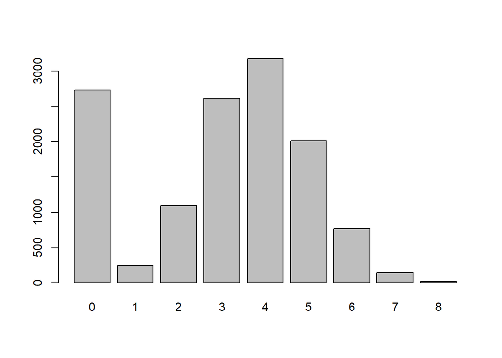

```r
barplot(table(wine_raw$TARGET))
```

```r
class(wine_raw$TARGET)
```

```
## [1] "integer"
```

```r
summary(wine_raw$TARGET)
```

```
##    Min. 1st Qu.  Median    Mean 3rd Qu.    Max.
##   0.000   2.000   3.000   3.029   4.000   8.000
```

###### FixedAcidity

```r
summary(wine_raw$FixedAcidity)
```

```
##    Min. 1st Qu.  Median    Mean 3rd Qu.    Max.
## -18.100   5.200   6.900   7.076   9.500  34.400
```

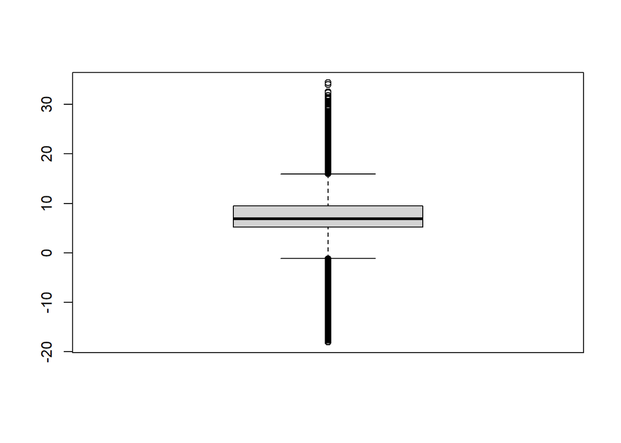

```r
boxplot(wine_raw$FixedAcidity)
```

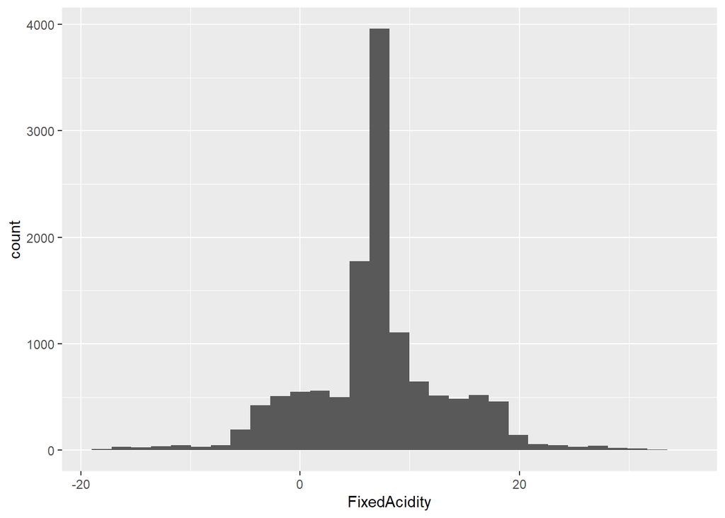

```r
ggplot(wine_raw, aes(FixedAcidity)) + geom_histogram()
```

###### VolatileAcidity

```r
summary(wine_raw$VolatileAcidity)
```

```
##    Min. 1st Qu.  Median    Mean 3rd Qu.    Max.
## -2.7900  0.1300  0.2800  0.3241  0.6400  3.6800
```

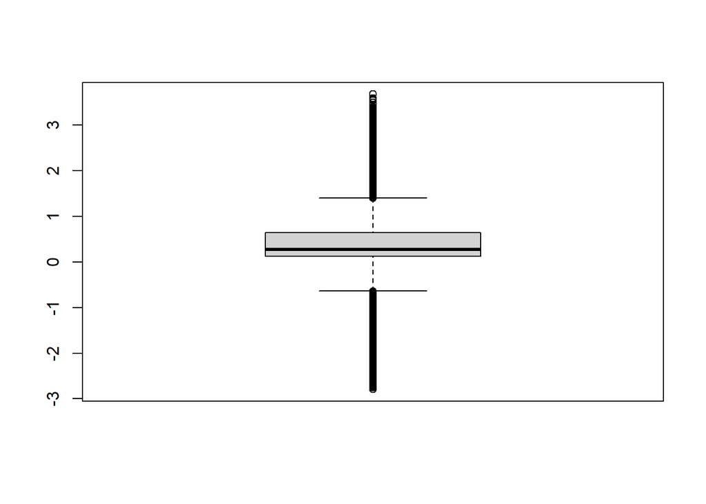

```r
boxplot(wine_raw$VolatileAcidity)
```

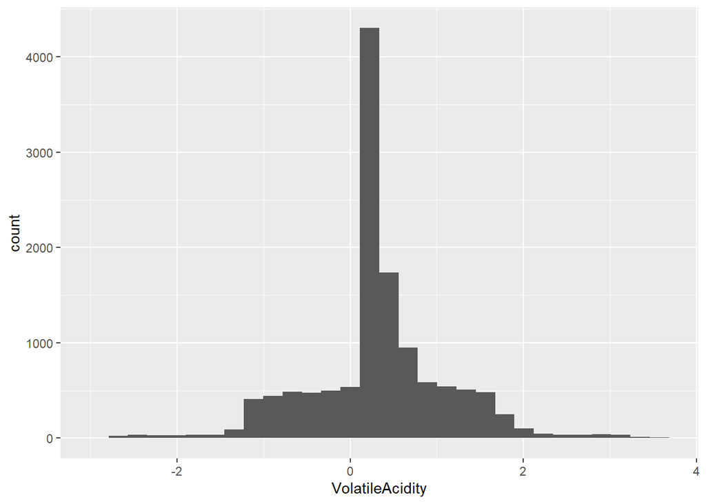

```r
ggplot(wine_raw, aes(VolatileAcidity)) + geom_histogram()
```

### CitricAcid

```r
summary(wine_raw$CitricAcid)
```

```
##    Min. 1st Qu.  Median    Mean 3rd Qu.    Max.
## -3.2400  0.0300  0.3100  0.3084  0.5800  3.8600
```

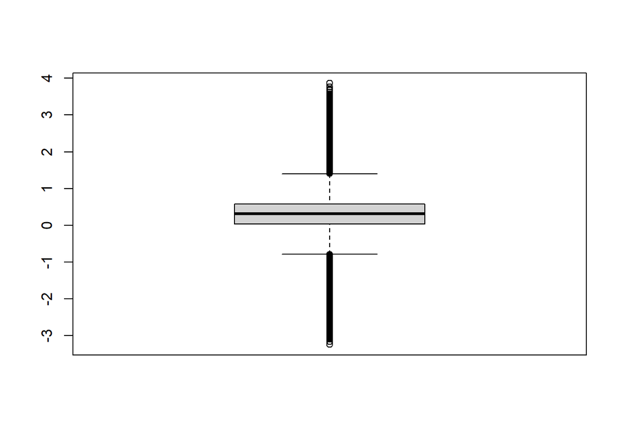

```r
boxplot(wine_raw$CitricAcid)
```

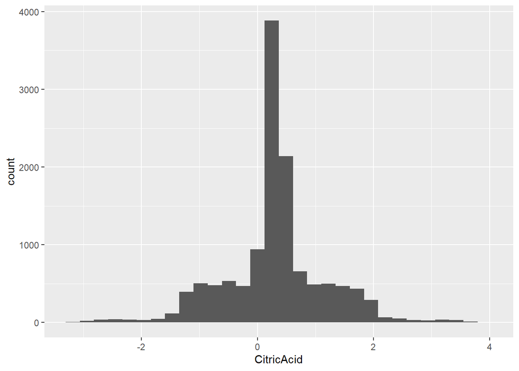

```r
ggplot(wine_raw, aes(CitricAcid)) + geom_histogram()
```

### ResidualSugar

```r
summary(wine_raw$ResidualSugar)
```

```
##     Min.  1st Qu.   Median     Mean  3rd Qu.     Max.     NA's
## -127.800   -2.000    3.900    5.419   15.900  141.150      616
```

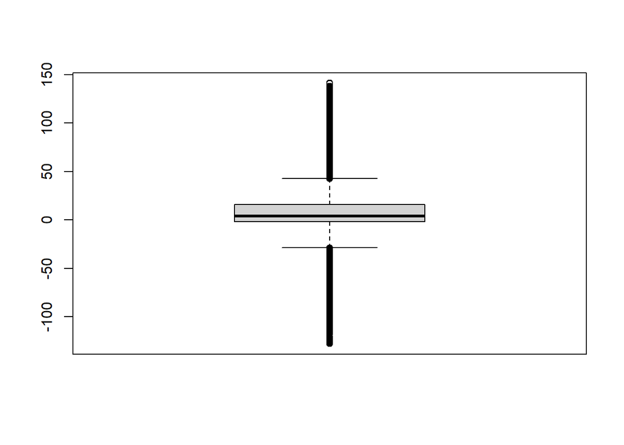

```r
boxplot(wine_raw$ResidualSugar)
```

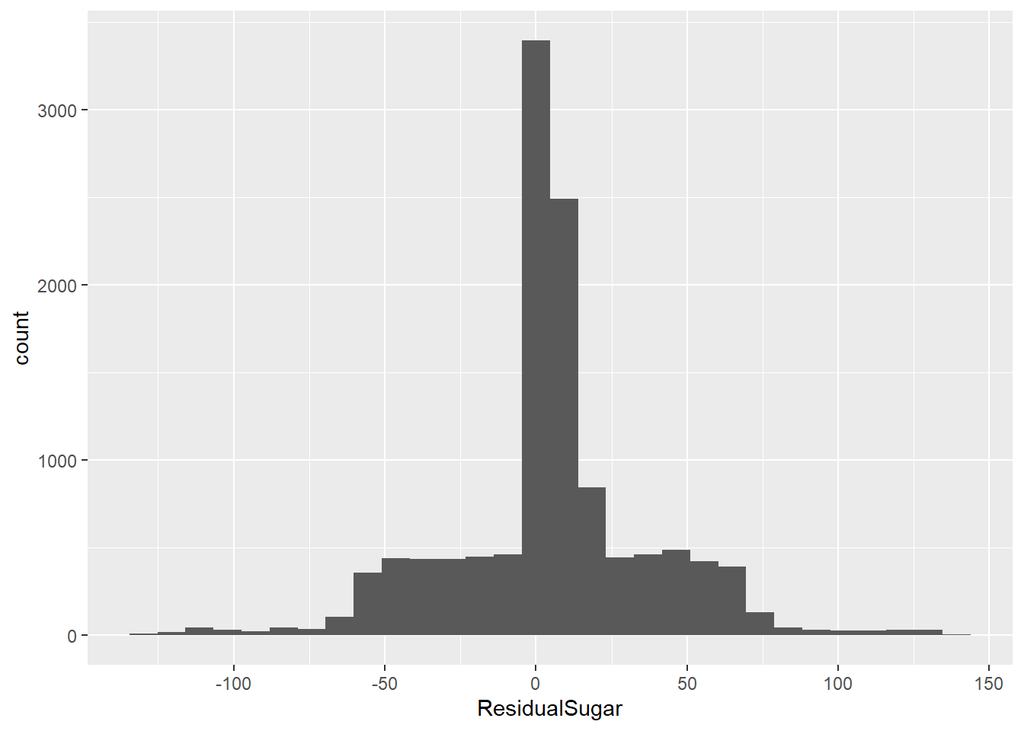

```r
ggplot(wine_raw, aes(ResidualSugar)) + geom_histogram()
```

### chlorides

```r
summary(wine_raw$Chlorides)
```

```
##    Min. 1st Qu.  Median    Mean 3rd Qu.    Max.    NA's
## -1.1710 -0.0310  0.0460  0.0548  0.1530  1.3510     638
```

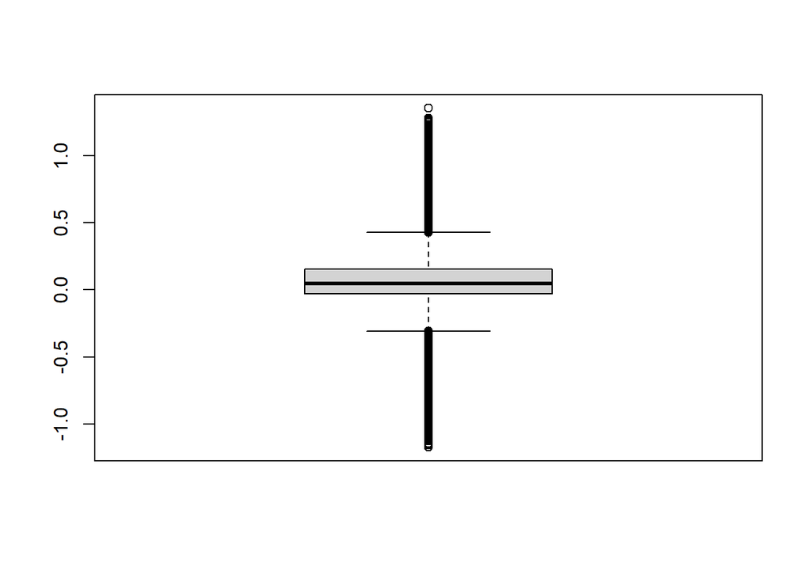

```r
boxplot(wine_raw$Chlorides)
```

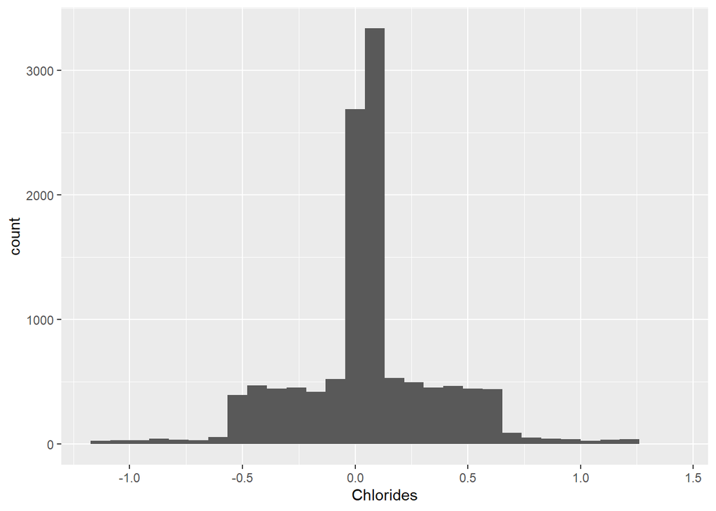

```r
ggplot(wine_raw, aes(Chlorides)) + geom_histogram()
```

### FreeSulfurDioxide

```r
summary(wine_raw$FreeSulfurDioxide)
```

```
##    Min. 1st Qu.  Median    Mean 3rd Qu.    Max.    NA's
## -555.00    0.00   30.00   30.85   70.00  623.00     647
```

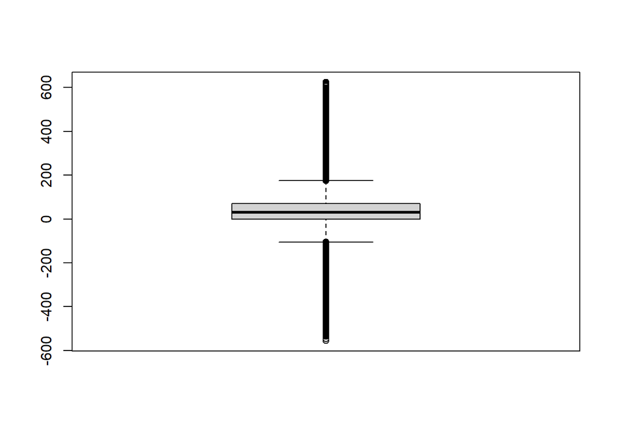

```r
boxplot(wine_raw$FreeSulfurDioxide)
```

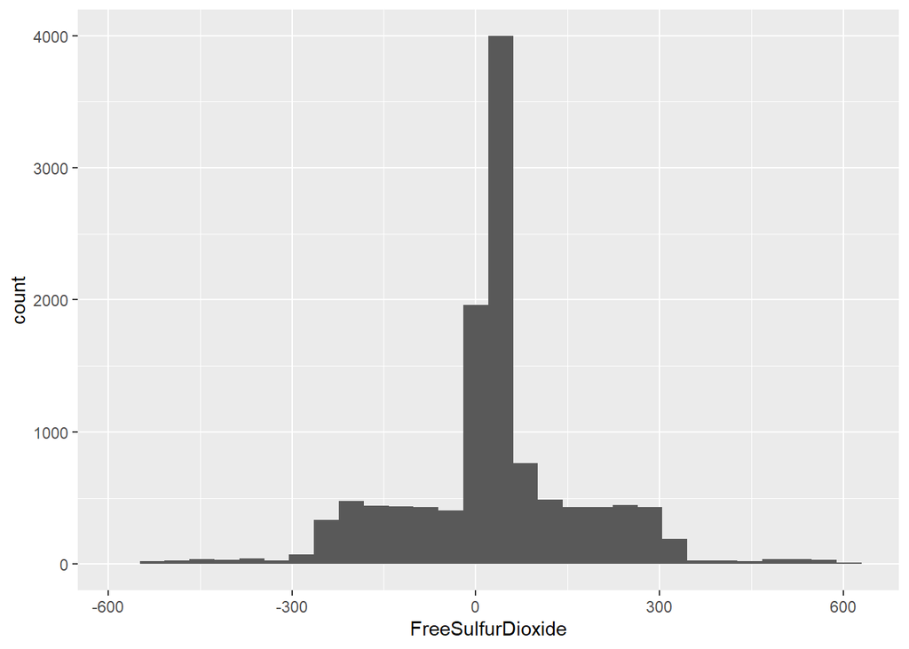

```r
ggplot(wine_raw, aes(FreeSulfurDioxide)) + geom_histogram()
```

### TotalSulfurDioxide

```r
summary(wine_raw$TotalSulfurDioxide)
```

```
##    Min. 1st Qu.  Median    Mean 3rd Qu.    Max.    NA's
##  -823.0    27.0   123.0   120.7   208.0  1057.0     682
```

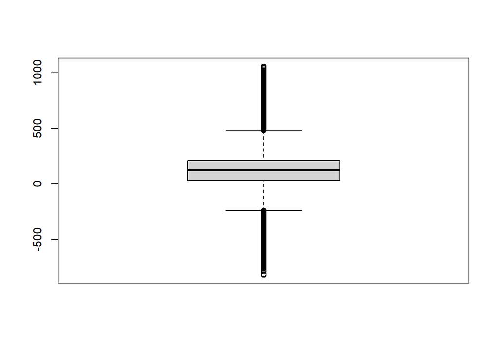

```r
boxplot(wine_raw$TotalSulfurDioxide)
```

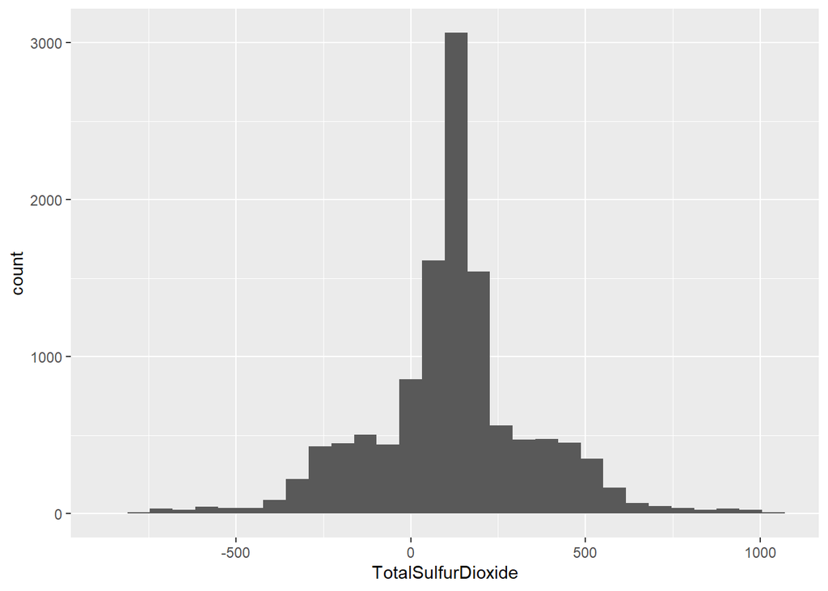

```r
ggplot(wine_raw, aes(TotalSulfurDioxide)) + geom_histogram()
```

### Density

```r
summary(wine_raw$Density)
```

```
##    Min. 1st Qu.  Median    Mean 3rd Qu.    Max.
##  0.8881  0.9877  0.9945  0.9942  1.0005  1.0992
```

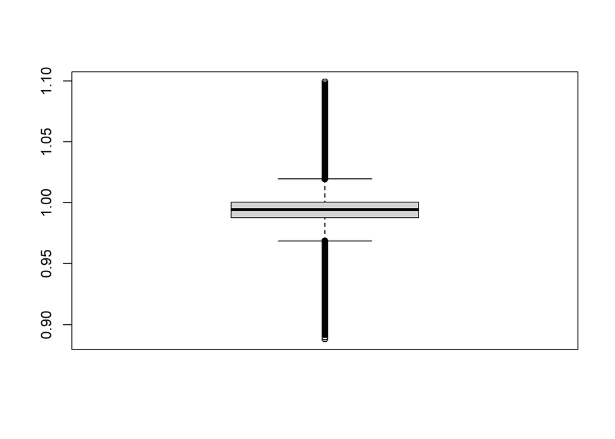

```r
boxplot(wine_raw$Density)
```

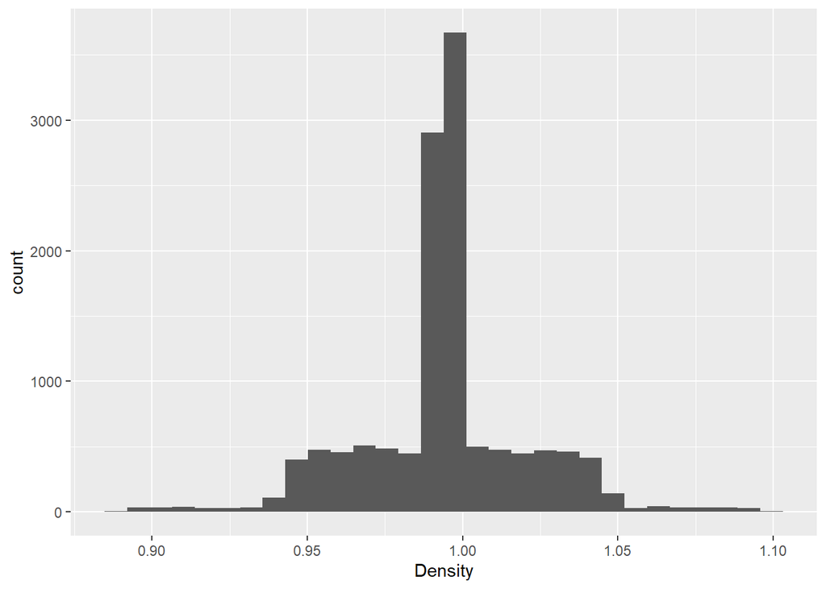

```r
ggplot(wine_raw, aes(Density)) + geom_histogram()
```

### pH

```r
summary(wine_raw$pH)
```

```
##    Min. 1st Qu.  Median    Mean 3rd Qu.    Max.    NA's
##   0.480   2.960   3.200   3.208   3.470   6.130     395
```

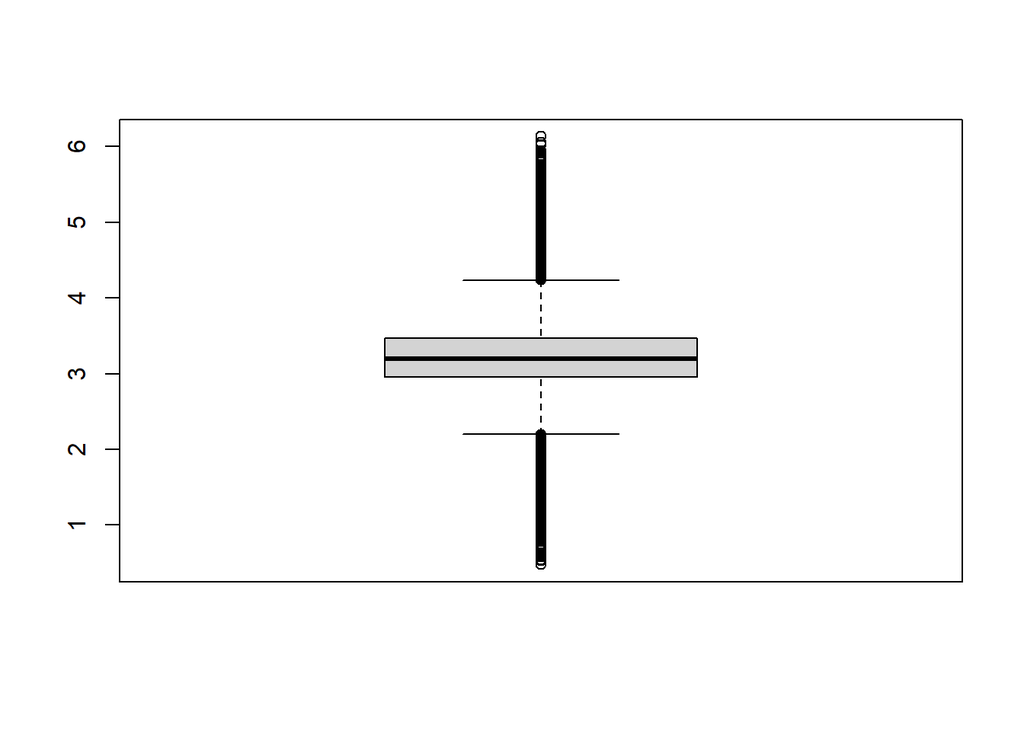

```r
boxplot(wine_raw$pH)
```

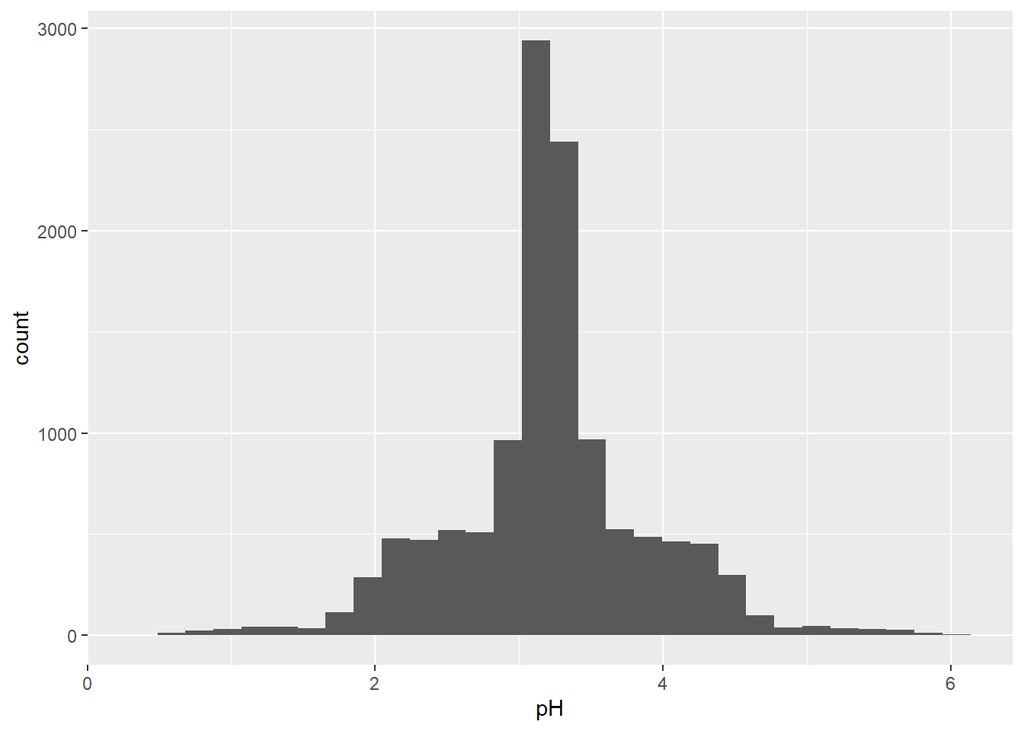

```r
ggplot(wine_raw, aes(pH)) + geom_histogram()
```

### Sulphates

```r
summary(wine_raw$Sulphates)
```

```
##    Min. 1st Qu.  Median    Mean 3rd Qu.    Max.    NA's
## -3.1300  0.2800  0.5000  0.5271  0.8600  4.2400    1210
```

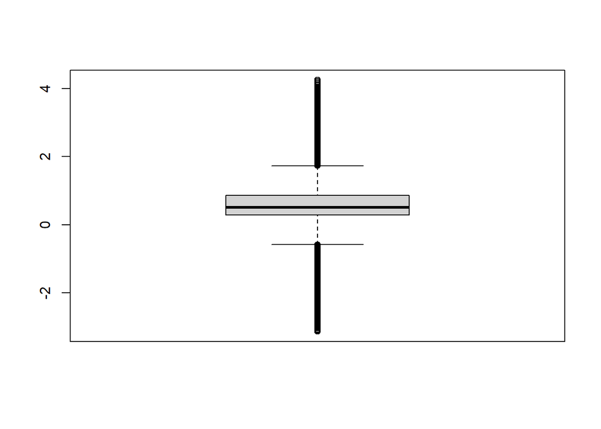

```r
boxplot(wine_raw$Sulphates)
```

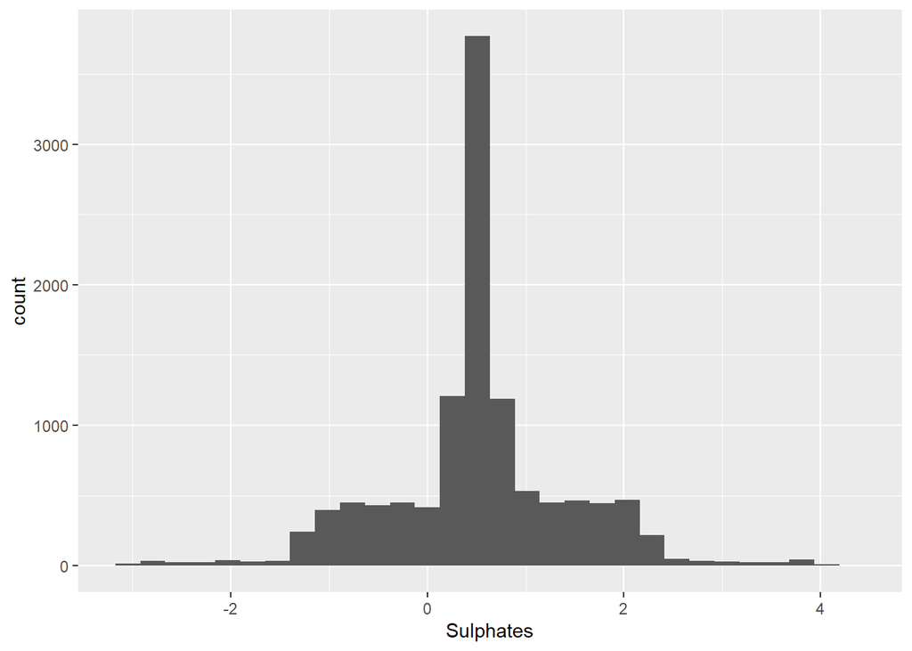

```r
ggplot(wine_raw, aes(Sulphates)) + geom_histogram()
```

### Alcohol

```r
summary(wine_raw$Alcohol)
```

```
##    Min. 1st Qu.  Median    Mean 3rd Qu.    Max.    NA's
##   -4.70    9.00   10.40   10.49   12.40   26.50     653
```

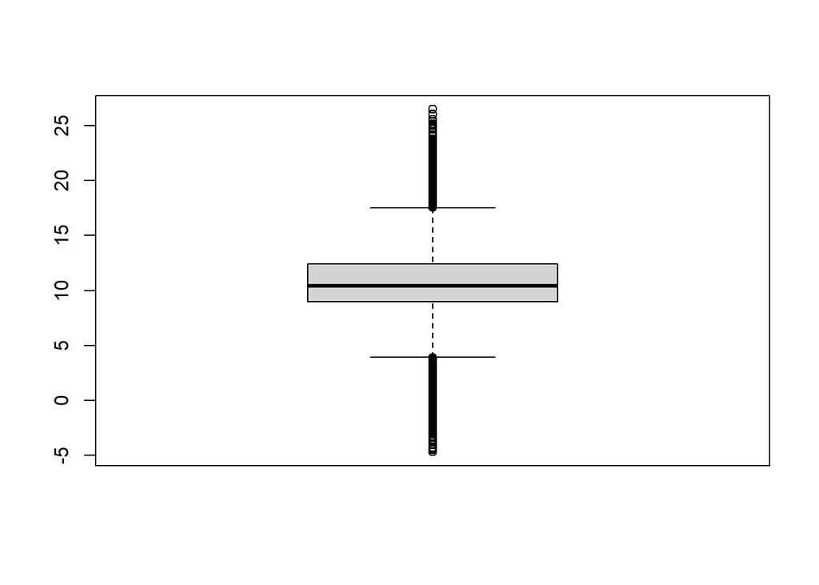

```r
boxplot(wine_raw$Alcohol)
```

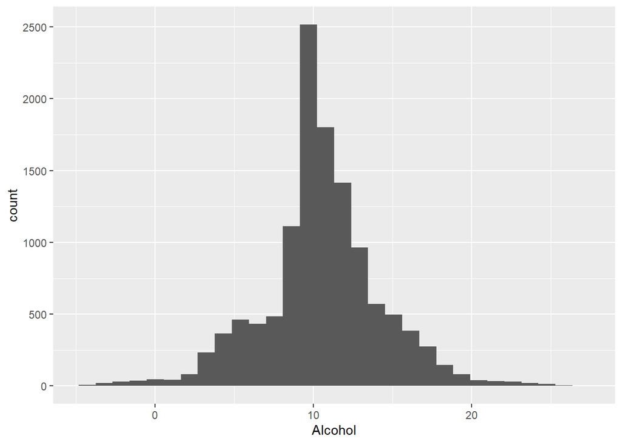

```r
ggplot(wine_raw, aes(Alcohol)) + geom_histogram()
```

### LabelAppeal

```r
summary(wine_raw$LabelAppeal)
```

```
##      Min.   1st Qu.    Median      Mean   3rd Qu.      Max.
## -2.000000 -1.000000  0.000000 -0.009066  1.000000  2.000000
```

```r
unique(wine_raw$LabelAppeal)
```

```
## [1]  0 -1  1  2 -2
```

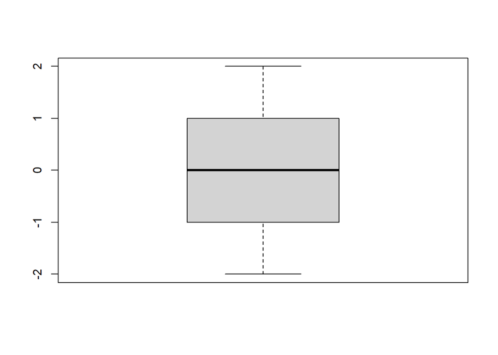

```r
boxplot(wine_raw$LabelAppeal)
```

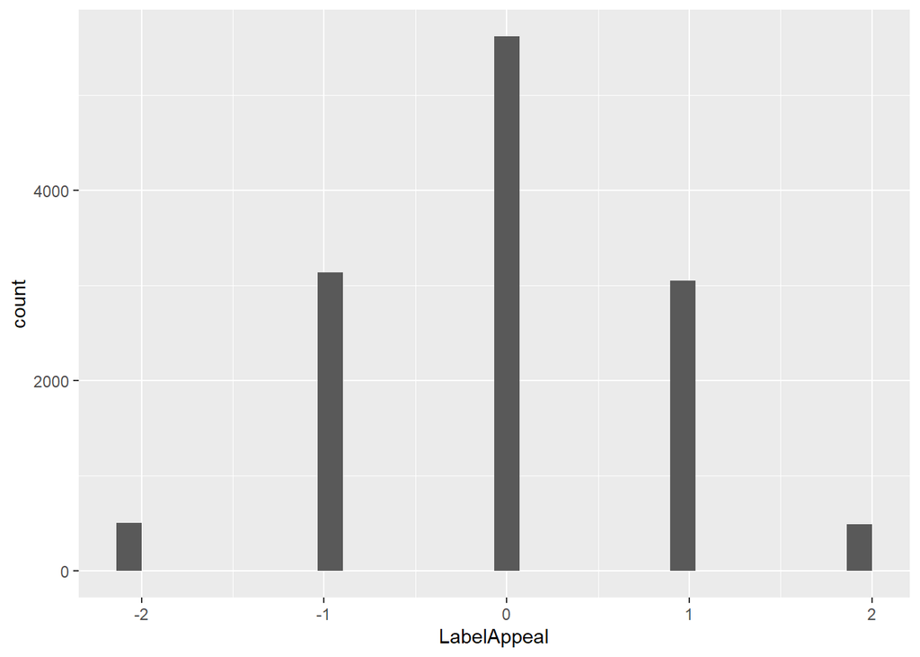

```r
ggplot(wine_raw, aes(LabelAppeal)) + geom_histogram()
```

### AcidIndex

```r
summary(wine_raw$AcidIndex)
```

```
##    Min. 1st Qu.  Median    Mean 3rd Qu.    Max.
##   4.000   7.000   8.000   7.773   8.000  17.000
```

```r
unique(wine_raw$AcidIndex)
```

```
##  [1]  8  7  6  9 11  5 10 14 13 12 16 15 17  4
```

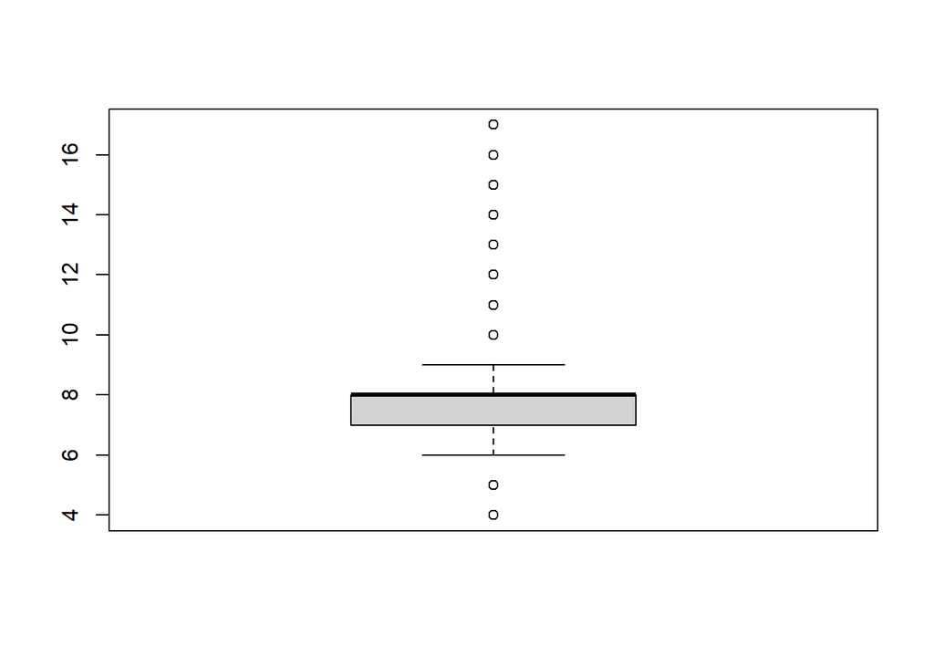

```r
boxplot(wine_raw$AcidIndex)
```

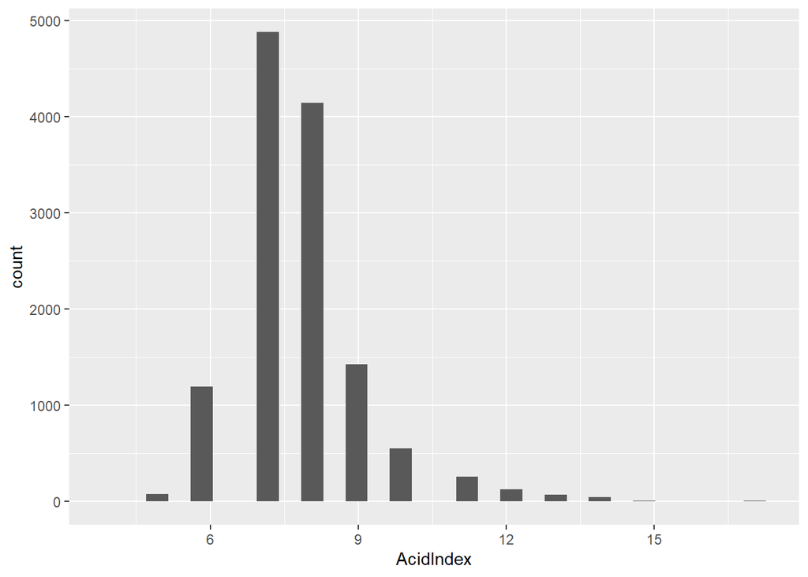

```r
ggplot(wine_raw, aes(AcidIndex)) + geom_histogram()
```

### STARS

```r
summary(wine_raw$STARS)
```

```
##    Min. 1st Qu.  Median    Mean 3rd Qu.    Max.    NA's
##   1.000   1.000   2.000   2.042   3.000   4.000    3359
```

```r
unique(wine_raw$STARS)
```

```
## [1]  2  3  1 NA  4
```

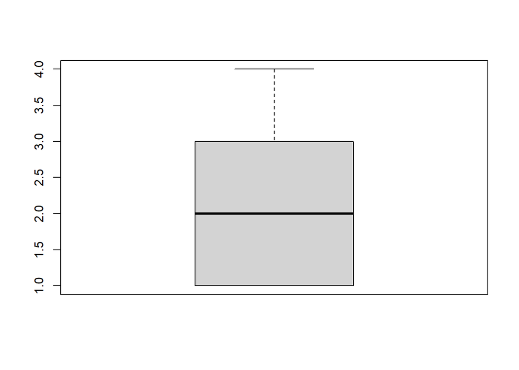

```r
boxplot(wine_raw$STARS)
```

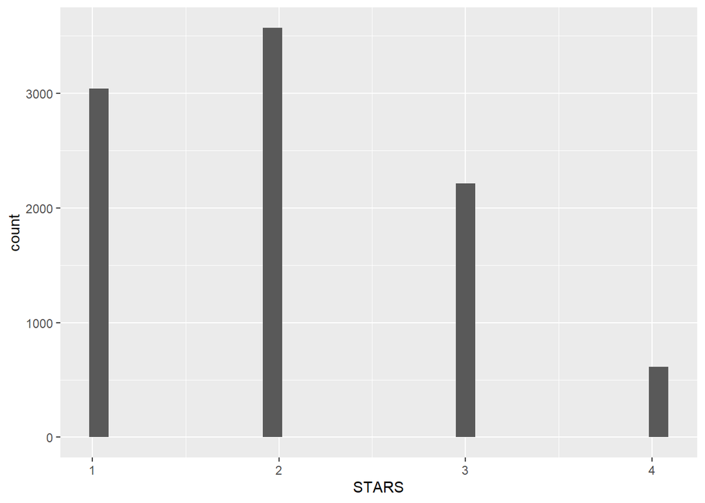

```r
ggplot(wine_raw, aes(STARS)) + geom_histogram()
```

#### Imputing Missing data

```r
### Imputing missing values
summary(wine_raw$ResidualSugar)
```

```
##     Min.  1st Qu.   Median     Mean  3rd Qu.     Max.     NA's
## -127.800   -2.000    3.900    5.419   15.900  141.150      616
```

```r
summary(wine_raw$Chlorides)
```

```
##    Min. 1st Qu.  Median    Mean 3rd Qu.    Max.    NA's
## -1.1710 -0.0310  0.0460  0.0548  0.1530  1.3510     638
```

```r
summary(wine_raw$FreeSulfurDioxide)
```

```
##    Min. 1st Qu.  Median    Mean 3rd Qu.    Max.    NA's
## -555.00    0.00   30.00   30.85   70.00  623.00     647
```

```r
summary(wine_raw$TotalSulfurDioxide)
```

```
##    Min. 1st Qu.  Median    Mean 3rd Qu.    Max.    NA's
##  -823.0    27.0   123.0   120.7   208.0  1057.0     682
```

```r
summary(wine_raw$pH)
```

```
##    Min. 1st Qu.  Median    Mean 3rd Qu.    Max.    NA's
##   0.480   2.960   3.200   3.208   3.470   6.130     395
```

```r
summary(wine_raw$Sulphates)
```

```
##    Min. 1st Qu.  Median    Mean 3rd Qu.    Max.    NA's
## -3.1300  0.2800  0.5000  0.5271  0.8600  4.2400    1210
```

```r
summary(wine_raw$Alcohol)
```

```
##    Min. 1st Qu.  Median    Mean 3rd Qu.    Max.    NA's
##   -4.70    9.00   10.40   10.49   12.40   26.50     653
```

```r
summary(wine_raw$STARS)
```

```
##    Min. 1st Qu.  Median    Mean 3rd Qu.    Max.    NA's
##   1.000   1.000   2.000   2.042   3.000   4.000    3359
```

As we see above the column STARS has a very big number of data missing, so we won’t impute this column. Rather we will remove this column first for our impute efforts and then will put it back to the imputed dataset.

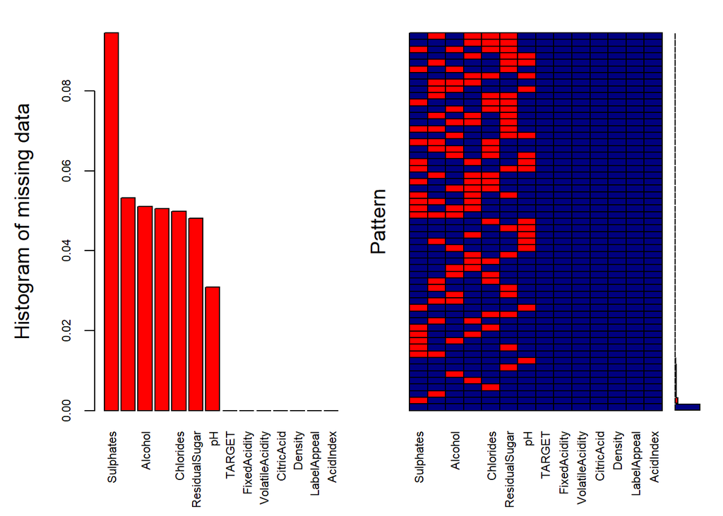

```
##
##  Variables sorted by number of missings:
##            Variable      Count
##           Sulphates 0.09456819
##  TotalSulfurDioxide 0.05330207
##             Alcohol 0.05103556
##   FreeSulfurDioxide 0.05056663
##           Chlorides 0.04986323
##       ResidualSugar 0.04814381
##                  pH 0.03087143
##              TARGET 0.00000000
##        FixedAcidity 0.00000000
##     VolatileAcidity 0.00000000
##          CitricAcid 0.00000000
##             Density 0.00000000
##         LabelAppeal 0.00000000
##           AcidIndex 0.00000000
```

```r
wine_raw3 <- subset(wine_raw, select = -c(STARS))

aggr_plot3 <- aggr(wine_raw3, col=c('navyblue','red'),
                  numbers=TRUE, sortVars=TRUE,
                  labels=names(wine_raw3), cex.axis=.7,
                  gap=3, ylab=c("Histogram of missing data","Pattern"))
```

```r
wine_raw_imputed <- mice(data = wine_raw3, m = 1,
                         method = "pmm", maxit = 5, seed = 500)
wine_raw_imputed_df <- mice::complete(wine_raw_imputed, 1)
wine_raw_imputed_df_bk <- wine_raw_imputed_df

wine_raw_imputed_df <- cbind(wine_raw_imputed_df, wine_raw[, "STARS"])

colnames(wine_raw_imputed_df)[colnames(wine_raw_imputed_df) == 'wine_raw[, "STARS"]'] <-
  "STARS"
```

We have imputed all fields except STARS. Let’s compare the raw dataset columns having NA and the same columns in the imputed dataset.

```r
summary(wine_raw$ResidualSugar)
```

```
##     Min.  1st Qu.   Median     Mean  3rd Qu.     Max.     NA's
## -127.800   -2.000    3.900    5.419   15.900  141.150      616
```

```r
summary(wine_raw_imputed_df$ResidualSugar)
```

```
##     Min.  1st Qu.   Median     Mean  3rd Qu.     Max.
## -127.800   -2.000    3.850    5.459   16.000  141.150
```

```r
summary(wine_raw$Chlorides)
```

```
##    Min. 1st Qu.  Median    Mean 3rd Qu.    Max.    NA's
## -1.1710 -0.0310  0.0460  0.0548  0.1530  1.3510     638
```

```r
summary(wine_raw_imputed_df$Chlorides)
```

```
##    Min. 1st Qu.  Median    Mean 3rd Qu.    Max.
## -1.1710 -0.0290  0.0460  0.0555  0.1540  1.3510
```

```r
summary(wine_raw$FreeSulfurDioxide)
```

```
##    Min. 1st Qu.  Median    Mean 3rd Qu.    Max.    NA's
## -555.00    0.00   30.00   30.85   70.00  623.00     647
```

```r
summary(wine_raw_imputed_df$FreeSulfurDioxide)
```

```
##    Min. 1st Qu.  Median    Mean 3rd Qu.    Max.
## -555.00    0.00   30.00   30.53   70.00  623.00
```

```r
summary(wine_raw$TotalSulfurDioxide)
```

```
##    Min. 1st Qu.  Median    Mean 3rd Qu.    Max.    NA's
##  -823.0    27.0   123.0   120.7   208.0  1057.0     682
```

```r
summary(wine_raw_imputed_df$TotalSulfurDioxide)
```

```
##    Min. 1st Qu.  Median    Mean 3rd Qu.    Max.
##    -823      27     124     121     209    1057
```

```r
summary(wine_raw$pH)
```

```
##    Min. 1st Qu.  Median    Mean 3rd Qu.    Max.    NA's
##   0.480   2.960   3.200   3.208   3.470   6.130     395
```

```r
summary(wine_raw_imputed_df$pH)
```

```
##    Min. 1st Qu.  Median    Mean 3rd Qu.    Max.
##   0.480   2.960   3.200   3.207   3.470   6.130
```

```r
summary(wine_raw$Sulphates)
```

```
##    Min. 1st Qu.  Median    Mean 3rd Qu.    Max.    NA's
## -3.1300  0.2800  0.5000  0.5271  0.8600  4.2400    1210
```

```r
summary(wine_raw_imputed_df$Sulphates)
```

```
##    Min. 1st Qu.  Median    Mean 3rd Qu.    Max.
## -3.1300  0.2800  0.5000  0.5267  0.8600  4.2400
```

```r
summary(wine_raw$Alcohol)
```

```
##    Min. 1st Qu.  Median    Mean 3rd Qu.    Max.    NA's
##   -4.70    9.00   10.40   10.49   12.40   26.50     653
```

```r
summary(wine_raw_imputed_df$Alcohol)
```

```
##    Min. 1st Qu.  Median    Mean 3rd Qu.    Max.
##   -4.70    9.00   10.40   10.49   12.40   26.50
```

```r
summary(wine_raw$STARS)
```

```
##    Min. 1st Qu.  Median    Mean 3rd Qu.    Max.    NA's
##   1.000   1.000   2.000   2.042   3.000   4.000    3359
```

```r
summary(wine_raw_imputed_df$STARS)
```

```
##    Min. 1st Qu.  Median    Mean 3rd Qu.    Max.    NA's
##   1.000   1.000   2.000   2.042   3.000   4.000    3359
```

##### Correlation checks

Let’s build the correlation plot.

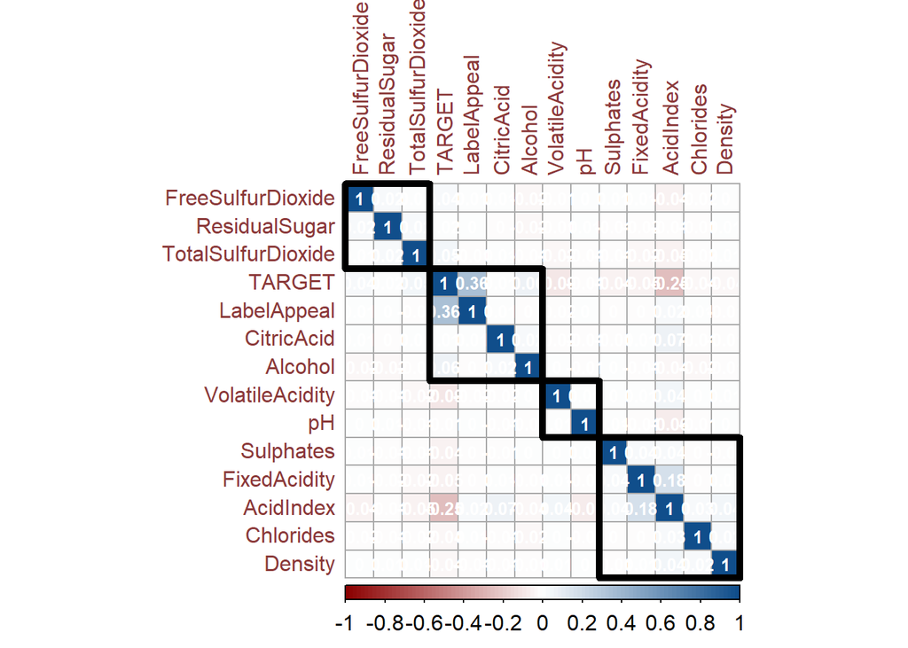

```r
corrMatrix <- round(cor(wine_raw_imputed_df_bk),4)

corrMatrix %>% corrplot(., method = "color", outline = T,
                        addgrid.col = "darkgray", order="hclust",
                        addrect = 4, rect.col = "black",
                        rect.lwd = 5,cl.pos = "b", tl.col = "indianred4",
                        tl.cex = 1.0, cl.cex = 1.0, addCoef.col = "white",
                        number.digits = 2, number.cex = 0.8,
                        col = colorRampPalette(c("darkred","white","dodgerblue4"))(100))
```

#### Splitting the dataset into test and train dataset

```r
n <- nrow(wine_raw_imputed_df)
set.seed(123)
wine_random_index <- wine_raw_imputed_df[sample(n), ]

wine.train.df <- wine_raw_imputed_df[1:as.integer(0.7*n),]

wine.test.df <- wine_raw_imputed_df[as.integer(0.7*n +1):n, ]

table(wine.test.df$TARGET) / nrow(wine.test.df)
```

```
##
##            0            1            2            3            4            5
## 0.2159416515 0.0187548841 0.0862203699 0.1997916124 0.2448554311 0.1604584527
##            6            7            8
## 0.0617348268 0.0114613181 0.0007814535
```

```r
table(wine.train.df$TARGET) / nrow(wine.train.df)
```

```
##
##           0           1           2           3           4           5
## 0.212706565 0.019205002 0.084859312 0.205895489 0.249776686 0.156096472
##           6           7           8
## 0.058954891 0.010942385 0.001563198
```

#### Building the first model for counts - using Poisson Regression

```r
poisson_model1 <- glm(formula = TARGET ~ . - STARS,
                      data = wine.train.df,
                      family = poisson)

summary(poisson_model1)
```

```
##
## Call:
## glm(formula = TARGET ~ . - STARS, family = poisson, data = wine.train.df)
##
## Deviance Residuals:
##     Min       1Q   Median       3Q      Max
## -3.5422  -0.2909   0.1061   0.3612   1.9325
##
## Coefficients:
##                      Estimate Std. Error z value Pr(>|z|)
## (Intercept)         1.997e+00  2.466e-01   8.097 5.65e-16 ***
## FixedAcidity        4.708e-04  1.041e-03   0.452  0.65095
## VolatileAcidity    -3.367e-02  8.192e-03  -4.110 3.95e-05 ***
## CitricAcid          1.827e-03  7.384e-03   0.247  0.80461
## ResidualSugar      -5.173e-05  1.918e-04  -0.270  0.78741
## Chlorides          -1.247e-02  2.039e-02  -0.612  0.54082
## FreeSulfurDioxide   6.858e-05  4.328e-05   1.584  0.11310
## TotalSulfurDioxide  3.438e-05  2.807e-05   1.225  0.22067
## Density            -3.158e-01  2.425e-01  -1.302  0.19282
## pH                 -1.173e-03  9.625e-03  -0.122  0.90299
## Sulphates          -1.116e-02  6.839e-03  -1.632  0.10273
## Alcohol             6.651e-03  1.747e-03   3.808  0.00014 ***
## LabelAppeal         2.468e-01  7.340e-03  33.631  < 2e-16 ***
## AcidIndex          -6.286e-02  5.780e-03 -10.876  < 2e-16 ***
## ---
## Signif. codes:  0 '***' 0.001 '**' 0.01 '*' 0.05 '.' 0.1 ' ' 1
##
## (Dispersion parameter for poisson family taken to be 1)
##
##     Null deviance: 6186.4  on 6640  degrees of freedom
## Residual deviance: 4872.0  on 6627  degrees of freedom
##   (2315 observations deleted due to missingness)
## AIC: 24584
##
## Number of Fisher Scoring iterations: 5
```

```r
length(predict(poisson_model1, newdata = wine.test.df))
```

```
## [1] 3839
```

```r
predict_model1_test <- predict(poisson_model1, newdata = wine.test.df,
                               type = "response") %>% round(0)

table(Predicted = predict_model1_test, Actual = wine.test.df$TARGET)
```

```
##          Actual
## Predicted   0   1   2   3   4   5   6   7   8
##         1   1   0   0   0   0   0   0   0   0
##         2  92  45  65  48  12   2   0   0   0
##         3 374  26 232 480 325  99  18   1   0
##         4 248   1  33 230 476 295  69   6   0
##         5  94   0   1   9 122 194 107  17   1
##         6  20   0   0   0   5  25  40  19   2
##         7   0   0   0   0   0   1   3   1   0
```

#### Second Poisson Regression model

Removing the statistically insignificant variables

```r
poisson_model2 <- glm(formula = TARGET ~ VolatileAcidity + Alcohol + LabelAppeal +
                        AcidIndex + FreeSulfurDioxide,
                      data = wine.train.df,
                      family = poisson)

summary(poisson_model2)
```

```
##
## Call:
## glm(formula = TARGET ~ VolatileAcidity + Alcohol + LabelAppeal +
##     AcidIndex + FreeSulfurDioxide, family = poisson, data = wine.train.df)
##
## Deviance Residuals:
##     Min       1Q   Median       3Q      Max
## -3.8252  -0.4734   0.2251   0.6327   2.9461
##
## Coefficients:
##                     Estimate Std. Error z value Pr(>|z|)
## (Intercept)        2.060e+00  4.424e-02  46.576  < 2e-16 ***
## VolatileAcidity   -6.424e-02  7.727e-03  -8.314  < 2e-16 ***
## Alcohol            8.201e-03  1.644e-03   4.988  6.1e-07 ***
## LabelAppeal        2.584e-01  6.836e-03  37.802  < 2e-16 ***
## AcidIndex         -1.361e-01  5.181e-03 -26.261  < 2e-16 ***
## FreeSulfurDioxide  1.108e-04  4.095e-05   2.706  0.00681 **
## ---
## Signif. codes:  0 '***' 0.001 '**' 0.01 '*' 0.05 '.' 0.1 ' ' 1
##
## (Dispersion parameter for poisson family taken to be 1)
##
##     Null deviance: 15931  on 8955  degrees of freedom
## Residual deviance: 13630  on 8950  degrees of freedom
## AIC: 36020
##
## Number of Fisher Scoring iterations: 5
```

```r
predict_model2_test <- predict(poisson_model2, newdata = wine.test.df,
                               type = "response") %>% round(0)

unique(wine.test.df$TARGET)
```

```
## [1] 3 2 0 4 5 6 7 1 8
```

```r
table(Predicted = predict_model2_test, Actual = wine.test.df$TARGET)
```

```
##          Actual
## Predicted   0   1   2   3   4   5   6   7   8
##         1  42   7   4   9   3   2   0   0   0
##         2 293  52 211 275 118  43   4   0   0
##         3 320  13 107 417 556 237  53   6   0
##         4 128   0   9  64 238 268 109  11   1
##         5  37   0   0   2  21  55  59  14   1
##         6   9   0   0   0   4   9   9  12   1
##         7   0   0   0   0   0   2   3   0   0
##         8   0   0   0   0   0   0   0   1   0
```

#### Third model - negative Binomial

```r
nb_model3 <- glm.nb(formula = TARGET ~ . - STARS,
                    data = wine.train.df)

summary(nb_model3)
```

```
##
## Call:
## glm.nb(formula = TARGET ~ . - STARS, data = wine.train.df, init.theta = 130133.7957,
##     link = log)
##
## Deviance Residuals:
##     Min       1Q   Median       3Q      Max
## -3.5422  -0.2909   0.1061   0.3612   1.9325
##
## Coefficients:
##                      Estimate Std. Error z value Pr(>|z|)
## (Intercept)         1.997e+00  2.466e-01   8.096 5.66e-16 ***
## FixedAcidity        4.708e-04  1.041e-03   0.452  0.65095
## VolatileAcidity    -3.367e-02  8.192e-03  -4.110 3.96e-05 ***
## CitricAcid          1.827e-03  7.384e-03   0.247  0.80462
## ResidualSugar      -5.173e-05  1.918e-04  -0.270  0.78742
## Chlorides          -1.247e-02  2.039e-02  -0.612  0.54082
## FreeSulfurDioxide   6.858e-05  4.328e-05   1.584  0.11311
## TotalSulfurDioxide  3.438e-05  2.807e-05   1.225  0.22068
## Density            -3.158e-01  2.425e-01  -1.302  0.19282
## pH                 -1.173e-03  9.625e-03  -0.122  0.90299
## Sulphates          -1.116e-02  6.839e-03  -1.632  0.10274
## Alcohol             6.651e-03  1.747e-03   3.808  0.00014 ***
## LabelAppeal         2.468e-01  7.340e-03  33.631  < 2e-16 ***
## AcidIndex          -6.286e-02  5.780e-03 -10.876  < 2e-16 ***
## ---
## Signif. codes:  0 '***' 0.001 '**' 0.01 '*' 0.05 '.' 0.1 ' ' 1
##
## (Dispersion parameter for Negative Binomial(130133.8) family taken to be 1)
##
##     Null deviance: 6186.3  on 6640  degrees of freedom
## Residual deviance: 4871.9  on 6627  degrees of freedom
##   (2315 observations deleted due to missingness)
## AIC: 24586
##
## Number of Fisher Scoring iterations: 1
##
##
##               Theta:  130134
##           Std. Err.:  225858
## Warning while fitting theta: iteration limit reached
##
##  2 x log-likelihood:  -24556.35
```

```r
predict_model3_test <- predict(nb_model3, newdata = wine.test.df,
                               type = "response") %>% round(0)

unique(wine.test.df$TARGET)
```

```
## [1] 3 2 0 4 5 6 7 1 8
```

```r
table(Predicted = predict_model3_test, Actual = wine.test.df$TARGET)
```

```
##          Actual
## Predicted   0   1   2   3   4   5   6   7   8
##         1   1   0   0   0   0   0   0   0   0
##         2  92  45  65  48  12   2   0   0   0
##         3 374  26 232 480 325  99  18   1   0
##         4 248   1  33 230 476 295  69   6   0
##         5  94   0   1   9 122 194 107  17   1
##         6  20   0   0   0   5  25  40  19   2
##         7   0   0   0   0   0   1   3   1   0
```

#### Fourth model - negative Binomial

Keeping only statistically relevant columns

```r
nb_model4 <- glm.nb(formula = TARGET ~ VolatileAcidity + Alcohol + LabelAppeal +
                      AcidIndex + FreeSulfurDioxide,
                    data = wine.train.df)

summary(nb_model4)
```

```
##
## Call:
## glm.nb(formula = TARGET ~ VolatileAcidity + Alcohol + LabelAppeal +
##     AcidIndex + FreeSulfurDioxide, data = wine.train.df, init.theta = 21485.40733,
##     link = log)
##
## Deviance Residuals:
##     Min       1Q   Median       3Q      Max
## -3.8249  -0.4734   0.2250   0.6326   2.9460
##
## Coefficients:
##                     Estimate Std. Error z value Pr(>|z|)
## (Intercept)        2.060e+00  4.424e-02  46.573  < 2e-16 ***
## VolatileAcidity   -6.424e-02  7.727e-03  -8.313  < 2e-16 ***
## Alcohol            8.201e-03  1.644e-03   4.988 6.11e-07 ***
## LabelAppeal        2.584e-01  6.836e-03  37.799  < 2e-16 ***
## AcidIndex         -1.361e-01  5.181e-03 -26.259  < 2e-16 ***
## FreeSulfurDioxide  1.108e-04  4.095e-05   2.706  0.00681 **
## ---
## Signif. codes:  0 '***' 0.001 '**' 0.01 '*' 0.05 '.' 0.1 ' ' 1
##
## (Dispersion parameter for Negative Binomial(21485.41) family taken to be 1)
##
##     Null deviance: 15929  on 8955  degrees of freedom
## Residual deviance: 13628  on 8950  degrees of freedom
## AIC: 36022
##
## Number of Fisher Scoring iterations: 1
##
##
##               Theta:  21485
##           Std. Err.:  63085
## Warning while fitting theta: iteration limit reached
##
##  2 x log-likelihood:  -36007.75
```

```r
predict_model4_test <- predict(nb_model4, newdata = wine.test.df,
                               type = "response") %>% round(0)


table(Predicted = predict_model4_test, Actual = wine.test.df$TARGET)
```

```
##          Actual
## Predicted   0   1   2   3   4   5   6   7   8
##         1  42   7   4   9   3   2   0   0   0
##         2 293  52 211 275 118  43   4   0   0
##         3 320  13 107 417 556 237  53   6   0
##         4 128   0   9  64 238 268 109  11   1
##         5  37   0   0   2  21  55  59  14   1
##         6   9   0   0   0   4   9   9  12   1
##         7   0   0   0   0   0   2   3   0   0
##         8   0   0   0   0   0   0   0   1   0
```

#### Fifth model - Zero Inflated Poisson regression

```r
zero_infl_model5 <- zeroinfl(formula = TARGET ~ VolatileAcidity + Alcohol +
                               LabelAppeal + AcidIndex + FreeSulfurDioxide,
                             data = wine.train.df)

summary(zero_infl_model5)
```

```
##
## Call:
## zeroinfl(formula = TARGET ~ VolatileAcidity + Alcohol + LabelAppeal +
##     AcidIndex + FreeSulfurDioxide, data = wine.train.df)
##
## Pearson residuals:
##     Min      1Q  Median      3Q     Max
## -2.1613 -0.3276  0.1986  0.4730  4.7777
##
## Count model coefficients (poisson with log link):
##                     Estimate Std. Error z value Pr(>|z|)
## (Intercept)        1.3544448  0.0490698  27.602  < 2e-16 ***
## VolatileAcidity   -0.0156830  0.0081099  -1.934 0.053135 .
## Alcohol            0.0088822  0.0017218   5.159 2.49e-07 ***
## LabelAppeal        0.2822315  0.0071411  39.522  < 2e-16 ***
## AcidIndex         -0.0201647  0.0058222  -3.463 0.000533 ***
## FreeSulfurDioxide  0.0000309  0.0000421   0.734 0.463024
##
## Zero-inflation model coefficients (binomial with logit link):
##                     Estimate Std. Error z value Pr(>|z|)
## (Intercept)       -5.5935003  0.2113997 -26.459  < 2e-16 ***
## VolatileAcidity    0.2754649  0.0402033   6.852 7.29e-12 ***
## Alcohol            0.0031498  0.0084878   0.371   0.7106
## LabelAppeal        0.1556141  0.0363168   4.285 1.83e-05 ***
## AcidIndex          0.4962748  0.0224163  22.139  < 2e-16 ***
## FreeSulfurDioxide -0.0005221  0.0002112  -2.473   0.0134 *
## ---
## Signif. codes:  0 '***' 0.001 '**' 0.01 '*' 0.05 '.' 0.1 ' ' 1
##
## Number of iterations in BFGS optimization: 16
## Log-likelihood: -1.601e+04 on 12 Df
```

```r
predict_model5_test_prob <- predict(zero_infl_model5, newdata = wine.test.df,
                               type = "prob")
predict_model5_test_final <- apply(predict_model5_test_prob,1,which.max)
predict_model5_test_final <- predict_model5_test_final - 1
table(predict_model5_test_final)
```

```
## predict_model5_test_final
##    0    1    2    3    4    5    6    7
## 1914    8  603  884  285  120   23    2
```

```r
table(Predicted = predict_model5_test_final, Actual = wine.test.df$TARGET)
```

```
##          Actual
## Predicted   0   1   2   3   4   5   6   7   8
##         0 535  35 134 323 419 306 137  23   2
##         1   2   3   3   0   0   0   0   0   0
##         2  97  34 163 219  74  15   1   0   0
##         3 124   0  31 217 337 152  23   0   0
##         4  46   0   0   6  95  94  40   4   0
##         5  20   0   0   2  13  44  31  10   0
##         6   5   0   0   0   2   5   4   6   1
##         7   0   0   0   0   0   0   1   1   0
```

##### Multiple Linear Regression models

```r
### Multiple Linear Regression 1
linear_model6 <- lm(formula = TARGET ~ . - STARS,
                    data = wine.train.df)

summary(linear_model6)
```

```
##
## Call:
## lm(formula = TARGET ~ . - STARS, data = wine.train.df)
##
## Residuals:
##     Min      1Q  Median      3Q     Max
## -5.7121 -0.5628  0.2044  0.6820  3.7518
##
## Coefficients:
##                      Estimate Std. Error t value Pr(>|t|)
## (Intercept)         6.137e+00  6.189e-01   9.917  < 2e-16 ***
## FixedAcidity        1.772e-03  2.617e-03   0.677   0.4983
## VolatileAcidity    -1.222e-01  2.058e-02  -5.940 2.99e-09 ***
## CitricAcid          6.713e-03  1.868e-02   0.359   0.7193
## ResidualSugar      -4.594e-05  4.813e-04  -0.095   0.9240
## Chlorides          -4.774e-02  5.106e-02  -0.935   0.3498
## FreeSulfurDioxide   2.476e-04  1.085e-04   2.282   0.0225 *
## TotalSulfurDioxide  1.303e-04  7.028e-05   1.855   0.0637 .
## Density            -1.093e+00  6.090e-01  -1.794   0.0728 .
## pH                 -2.908e-04  2.410e-02  -0.012   0.9904
## Sulphates          -3.843e-02  1.722e-02  -2.232   0.0257 *
## Alcohol             2.485e-02  4.359e-03   5.700 1.25e-08 ***
## LabelAppeal         9.015e-01  1.837e-02  49.076  < 2e-16 ***
## AcidIndex          -2.174e-01  1.376e-02 -15.799  < 2e-16 ***
## ---
## Signif. codes:  0 '***' 0.001 '**' 0.01 '*' 0.05 '.' 0.1 ' ' 1
##
## Residual standard error: 1.313 on 6627 degrees of freedom
##   (2315 observations deleted due to missingness)
## Multiple R-squared:  0.2955, Adjusted R-squared:  0.2941
## F-statistic: 213.8 on 13 and 6627 DF,  p-value: < 2.2e-16
```

```r
### Multiple Linear Regression 2
linear_model7 <- lm(formula = TARGET ~ VolatileAcidity + FreeSulfurDioxide +
                      TotalSulfurDioxide + Density + Sulphates + Alcohol +
                      LabelAppeal + AcidIndex,
                    data = wine.train.df)

summary(linear_model7)
```

```
##
## Call:
## lm(formula = TARGET ~ VolatileAcidity + FreeSulfurDioxide + TotalSulfurDioxide +
##     Density + Sulphates + Alcohol + LabelAppeal + AcidIndex,
##     data = wine.train.df)
##
## Residuals:
##     Min      1Q  Median      3Q     Max
## -5.9040 -0.6718  0.3951  1.1262  5.0353
##
## Coefficients:
##                      Estimate Std. Error t value Pr(>|t|)
## (Intercept)         7.435e+00  6.842e-01  10.868  < 2e-16 ***
## VolatileAcidity    -1.877e-01  2.308e-02  -8.133 4.75e-16 ***
## FreeSulfurDioxide   3.409e-04  1.219e-04   2.797  0.00517 **
## TotalSulfurDioxide  3.519e-04  7.813e-05   4.504 6.75e-06 ***
## Density            -1.854e+00  6.817e-01  -2.719  0.00655 **
## Sulphates          -5.117e-02  1.917e-02  -2.670  0.00760 **
## Alcohol             2.614e-02  4.875e-03   5.362 8.43e-08 ***
## LabelAppeal         7.829e-01  2.028e-02  38.608  < 2e-16 ***
## AcidIndex          -3.579e-01  1.362e-02 -26.282  < 2e-16 ***
## ---
## Signif. codes:  0 '***' 0.001 '**' 0.01 '*' 0.05 '.' 0.1 ' ' 1
##
## Residual standard error: 1.711 on 8947 degrees of freedom
## Multiple R-squared:  0.2083, Adjusted R-squared:  0.2076
## F-statistic: 294.3 on 8 and 8947 DF,  p-value: < 2.2e-16
```

```r
predict_model7_test <- predict(linear_model7, newdata = wine.test.df)
table(round(predict_model7_test,0))
```

```
##
##   -1    0    1    2    3    4    5    6
##    1   15  127  800 1692 1045  156    3
```

Based on the above analysis, we have decided to go with model5 which is zero Inflated Poisson model.

## Reference:

https://stats.idre.ucla.edu/r/dae/negative-binomial-regression/

https://stats.idre.ucla.edu/r/dae/zip/